# Module 4: Data Manipulation

Jacob Jameson  
Summer 2021

### Review: Packages

- Packages are collections of functions and data sets developed by the community.
- Two steps to use a package
  - installed with the install.packages function (only once)
  - imported with the library function (once per session)

```r
install.packages("package_name")
library(package_name)
```

### Let's Load Tidyverse

Go ahead and load the tidyverse package! This package includes:

- functions that allows us to read data into our RStudio environment, and;
- functions that allow us to manipulate our data.

```r
library(tidyverse)
```

[figure not shown]

### Review: Reading in Data

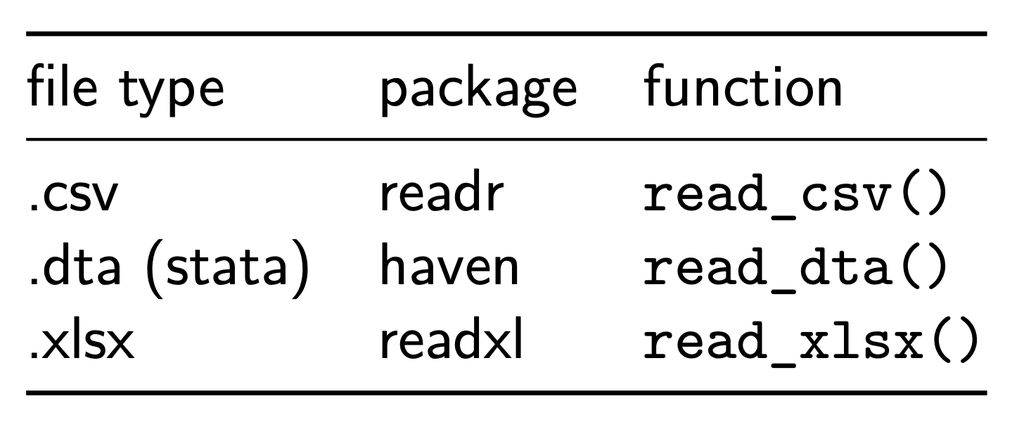

`tidyverse` includes the `readr` packages, but if we are wanting to read in data from another format we need to remember to load the correct package!

### Loading Data from Files

To load a file from your local directory, there are three steps:

1. Locate the directory of your file in the files tab
2. Set the directory as the working directory by More -> Set As Working Directory
3. Load the data into R using the correct function

```r
getwd()
```

```
[1] "/Users/jacob/Downloads/Module 3"
```

```r
library(tidyverse)
library(haven)
housing_data = read_dta("texas_housing_data.dta")
```

### What Data do we have?

- head() and glimpse() provide ways to see part of your data.
- View() provides a more spreadsheet-like experience

```r
head(housing_data)
```

```
# A tibble: 6 x 8
  city     year month sales   volume median listings inventory
  <chr>   <dbl> <dbl> <dbl>    <dbl>  <dbl>    <dbl>     <dbl>
1 Abilene  2000     1    72  5380000  71400      701       6.3
2 Abilene  2000     2    98  6505000  58700      746       6.6
3 Abilene  2000     3   130  9285000  58100      784       6.8
4 Abilene  2000     4    98  9730000  68600      785       6.9
5 Abilene  2000     5   141 10590000  67300      794       6.8
6 Abilene  2000     6   156 13910000  66900      780       6.6
```

### Quick Glance

Get number of rows and columns

```r
dim(housing_data)
```

```
[1] 8602    8
```

See column medians for numeric variables

```r
sapply(housing_data, median, na.rm=TRUE)
```

```
      city       year      month      sales     volume     median   listings
        NA     2007.0        6.0      169.0 22986824.0   123800.0     1283.0
 inventory
       6.2
```

### Data manipulation with dplyr

Once you have data in R, you’ll want to explore it. The tidyverse package dplyr provides a toolkit for data manipulation. We will cover:

- select() to pick columns
- arrange() to order the data
- mutate() to create new columns
- filter() to get rows that meet a criteria

### Selecting columns with select()

select() allows you to select specific columns of your data and create a subset.

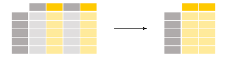

### Selecting columns with select()

Use case: You want to present a subset of your columns

```r
select(housing_data, city, sales, listings)
```

```
# A tibble: 8,602 x 3
   city    sales listings
   <chr>   <dbl>    <dbl>
 1 Abilene    72      701
 2 Abilene    98      746
 3 Abilene   130      784
 4 Abilene    98      785
 5 Abilene   141      794
 6 Abilene   156      780
 7 Abilene   152      742
 8 Abilene   131      765
 9 Abilene   104      771
10 Abilene   101      764
# … with 8,592 more rows
```

### Selecting columns with select()

Use case: You want to present a subset of your columns

```r
select(housing_data, -c(city, sales, listings))
```

```
# A tibble: 8,602 x 5
    year month   volume median inventory
   <dbl> <dbl>    <dbl>  <dbl>     <dbl>
 1  2000     1  5380000  71400       6.3
 2  2000     2  6505000  58700       6.6
 3  2000     3  9285000  58100       6.8
 4  2000     4  9730000  68600       6.9
 5  2000     5 10590000  67300       6.8
 6  2000     6 13910000  66900       6.6
 7  2000     7 12635000  73500       6.2
 8  2000     8 10710000  75000       6.4
 9  2000     9  7615000  64500       6.5
10  2000    10  7040000  59300       6.6
# … with 8,592 more rows
```

The - says to exclude the columns listed in the vector c().

### Selecting columns with select(), helpers

Use case: You want to reorder your columns

```r
select(housing_data, city, sales, listings, everything())
```

```
# A tibble: 8,602 x 8
   city    sales listings  year month   volume median inventory
   <chr>   <dbl>    <dbl> <dbl> <dbl>    <dbl>  <dbl>     <dbl>
 1 Abilene    72      701  2000     1  5380000  71400       6.3
 2 Abilene    98      746  2000     2  6505000  58700       6.6
 3 Abilene   130      784  2000     3  9285000  58100       6.8
 4 Abilene    98      785  2000     4  9730000  68600       6.9
 5 Abilene   141      794  2000     5 10590000  67300       6.8
 6 Abilene   156      780  2000     6 13910000  66900       6.6
 7 Abilene   152      742  2000     7 12635000  73500       6.2
 8 Abilene   131      765  2000     8 10710000  75000       6.4
 9 Abilene   104      771  2000     9  7615000  64500       6.5
10 Abilene   101      764  2000    10  7040000  59300       6.6
# … with 8,592 more rows
```

### Sort rows with arrange()

arrange() allows you to order your data

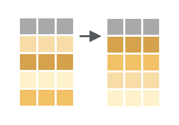

### Sort rows with arrange()

arrange() allows you to order your data

```r
arrange(housing_data, year)
```

```
# A tibble: 8,602 x 8
   city     year month sales   volume median listings inventory
   <chr>   <dbl> <dbl> <dbl>    <dbl>  <dbl>    <dbl>     <dbl>
 1 Abilene  2000     1    72  5380000  71400      701       6.3
 2 Abilene  2000     2    98  6505000  58700      746       6.6
 3 Abilene  2000     3   130  9285000  58100      784       6.8
 4 Abilene  2000     4    98  9730000  68600      785       6.9
 5 Abilene  2000     5   141 10590000  67300      794       6.8
 6 Abilene  2000     6   156 13910000  66900      780       6.6
 7 Abilene  2000     7   152 12635000  73500      742       6.2
 8 Abilene  2000     8   131 10710000  75000      765       6.4
 9 Abilene  2000     9   104  7615000  64500      771       6.5
10 Abilene  2000    10   101  7040000  59300      764       6.6
# … with 8,592 more rows
```

### Sort rows with arrange()

To change the order of use desc()

```r
arrange(housing_data, desc(year))
```

```
# A tibble: 8,602 x 8
   city      year month sales   volume median listings inventory
   <chr>    <dbl> <dbl> <dbl>    <dbl>  <dbl>    <dbl>     <dbl>
 1 Abilene   2015     1   158 23486998 134100      801       4.4
 2 Abilene   2015     2   151 19834263 126500      767       4.1
 3 Abilene   2015     3   198 31869437 136800      821       4.4
 4 Abilene   2015     4   201 28301159 129600      891       4.7
 5 Abilene   2015     5   199 31385757 144700      919       4.8
 6 Abilene   2015     6   260 41396230 141500      965       5
 7 Abilene   2015     7   268 45845730 148700      986       5
 8 Amarillo  2015     1   204 33188726 138500     1120       4.3
 9 Amarillo  2015     2   188 34355428 149400     1084       4.2
10 Amarillo  2015     3   317 53603130 140900     1051       3.9
# … with 8,592 more rows
```

### Introducing the pipe operator

[figure not shown]

Ceci est une pipe!

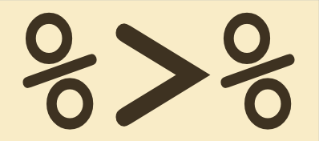

### Ceci est une %>%

The pipe %>% operator takes the left-hand side and makes it input in the right-hand side.

- by default, the left-hand side is the first argument of the right-hand side function.

```r
select(housing_data, city, year, sales, volume)
```

is equivalent to

```r
housing_data %>%
  select(city, year, sales, volume)
```

### Ceci est une %>%

We can chain together tidyverse functions to avoid making so many intermediate data frames!

```r
housing_data %>%
  select(city, year, sales, volume, median) %>%
  arrange(desc(median))
```

```
# A tibble: 8,602 x 5
   city           year sales    volume median
   <chr>         <dbl> <dbl>     <dbl>  <dbl>
 1 Collin County  2015  1572 544545110 304200
 2 Collin County  2015  1789 614959441 300400
 3 Collin County  2015  1861 613669702 292600
 4 Collin County  2015  1391 456997967 291400
 5 Collin County  2015  1258 413242198 285800
 6 Fort Bend      2015  1341 429731131 284200
 7 Collin County  2015   938 300904769 283400
 8 Midland        2014   208  70836346 283100
 9 Fort Bend      2014  1388 437581291 282300
10 Fort Bend      2015  1372 431875327 280400
# … with 8,592 more rows
```

### Creating columns with mutate()

When we mutate(), you can create new columns using existing columns!

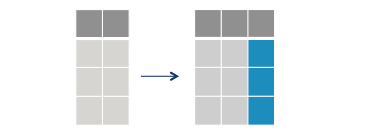

### Creating columns with mutate()

When we mutate(), you can create new columns using existing columns!

### Creating columns with mutate()

```r
housing_data %>%
  mutate(mean_price = volume / sales) %>%
  select(city, year, month, mean_price, sales, volume)
```

```
# A tibble: 8,602 x 6
   city     year month mean_price sales   volume
   <chr>   <dbl> <dbl>      <dbl> <dbl>    <dbl>
 1 Abilene  2000     1     74722.    72  5380000
 2 Abilene  2000     2     66378.    98  6505000
 3 Abilene  2000     3     71423.   130  9285000
 4 Abilene  2000     4     99286.    98  9730000
 5 Abilene  2000     5     75106.   141 10590000
 6 Abilene  2000     6     89167.   156 13910000
 7 Abilene  2000     7     83125    152 12635000
 8 Abilene  2000     8     81756.   131 10710000
 9 Abilene  2000     9     73221.   104  7615000
10 Abilene  2000    10     69703.   101  7040000
# … with 8,592 more rows
```

### Creating columns with mutate()

You can create multiple columns at a single time and even use information from a newly created column as input.

```r
housing_data %>%
  mutate(mean_price = volume / sales,
         sqrt_mean_price = sqrt(mean_price)) %>%
  select(city, year, month, mean_price, sales, sqrt_mean_price)
```

```
# A tibble: 8,602 x 6
   city     year month mean_price sales sqrt_mean_price
   <chr>   <dbl> <dbl>      <dbl> <dbl>           <dbl>
 1 Abilene  2000     1     74722.    72            273.
 2 Abilene  2000     2     66378.    98            258.
 3 Abilene  2000     3     71423.   130            267.
 4 Abilene  2000     4     99286.    98            315.
 5 Abilene  2000     5     75106.   141            274.
 6 Abilene  2000     6     89167.   156            299.
 7 Abilene  2000     7     83125    152            288.
 8 Abilene  2000     8     81756.   131            286.
 9 Abilene  2000     9     73221.   104            271.
10 Abilene  2000    10     69703.   101            264.
# … with 8,592 more rows
```

### Choose rows that match a condition with filter()

filter()

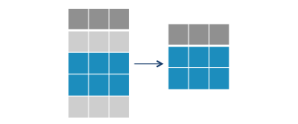

### Choose rows that match a condition with filter()

Get all the data from 2013

```r
filter(housing_data, year == 2013)
```

```
# A tibble: 552 x 8
   city     year month sales   volume median listings inventory
   <chr>   <dbl> <dbl> <dbl>    <dbl>  <dbl>    <dbl>     <dbl>
 1 Abilene  2013     1   114 15794494 125300      966       5.7
 2 Abilene  2013     2   140 16552641  94400      943       5.6
 3 Abilene  2013     3   164 19609711 102500      958       5.7
 4 Abilene  2013     4   213 27261796 113700      948       5.5
 5 Abilene  2013     5   225 31901380 130000      923       5.3
 6 Abilene  2013     6   209 29454125 127300      960       5.5
 7 Abilene  2013     7   218 32547446 140000      969       5.4
 8 Abilene  2013     8   236 30777727 120000      976       5.4
 9 Abilene  2013     9   195 26237106 127500      985       5.4
10 Abilene  2013    10   167 21781187 119000      993       5.5
# … with 542 more rows
```

```r
housing_data %>%
  filter(year == 2013)
```

### Choose rows that match a condition with filter()

We can use the logical operators we learned before to filter() for additional criteria!

```r
housing_data %>%
  filter(year == 2013,
         city == "Houston")
```

```
# A tibble: 12 x 8
   city     year month sales     volume median listings inventory
   <chr>   <dbl> <dbl> <dbl>      <dbl>  <dbl>    <dbl>     <dbl>
 1 Houston  2013     1  4273  852045057 149500    21364       3.7
 2 Houston  2013     2  4886 1060985674 161900    21293       3.6
 3 Houston  2013     3  6382 1479273481 172300    20909       3.5
 4 Houston  2013     4  7116 1770746764 182400    20607       3.4
 5 Houston  2013     5  8439 2121508529 186100    20526       3.3
 6 Houston  2013     6  7935 2073909387 191600    21008       3.3
 7 Houston  2013     7  8468 2168720825 187800    21497       3.3
 8 Houston  2013     8  8155 2083377894 186700    21366       3.3
 9 Houston  2013     9  6706 1638923780 180200    21207       3.2
10 Houston  2013    10  6551 1544551772 176000    20508       3.1
11 Houston  2013    11  5557 1356418081 181400    19331       2.9
12 Houston  2013    12  6380 1658872245 187500    17857       2.7
```

### Choose rows that match a condition with filter()

Additional filters using conditions

```r
housing_data %>%
  filter(year > 2013,
         city == "Houston" | city == "Austin")
```

```
# A tibble: 38 x 8
   city    year month sales     volume median listings inventory
   <chr>  <dbl> <dbl> <dbl>      <dbl>  <dbl>    <dbl>     <dbl>
 1 Austin  2014     1  1582  426127544 213700     5118       2
 2 Austin  2014     2  1903  550882376 229400     5255       2.1
 3 Austin  2014     3  2434  717821612 235600     5512       2.2
 4 Austin  2014     4  2691  813253968 237000     5838       2.3
 5 Austin  2014     5  3178 1012123948 243900     6539       2.6
 6 Austin  2014     6  3195 1023051880 248900     7040       2.7
 7 Austin  2014     7  3151  982086356 246900     7475       2.9
 8 Austin  2014     8  3023  927019222 243800     7326       2.9
 9 Austin  2014     9  2664  813797562 238900     7072       2.8
10 Austin  2014    10  2588  796863816 239600     6791       2.7
# … with 28 more rows
```

### Recap: manipulating data with dplyr

We learned:

- how to employ the 4 dplyr verbs of highest importance including:
  - select() to pick columns
  - arrange() to order the data
  - mutate() to create new columns
  - filter() to get rows that meet a criteria
- how logical operators in dplyr contexts
- how to use %>%